# Example 3

Thomas Klebel

1 5 2020

# Taske desc

The data contains the quantity of ice cream (CONS) consumed by 29 persons during the months June to September. Explanantory variables are: INC (income of the person), TEMP (temperature in F), PRICE (Price). A regression analysis yields the following results:

|  | Estimate | Std. Error | t value | Pr(>jtj) |
| --- | --- | --- | --- | --- |
| (Intercept) | -6329.81 | 3105.35 | -2.04 | 0.05 |
| PRICE | 23.35 | 11.48 | 2.03 | 0.05 |
| INC | 78.08 | 36.43 | 2.14 | 0.04 |
| TEMP | 2.82 | 0.42 | 6.77 | 0.00 |
| PRICE:INC | -0.28 | 0.13 | -2.07 | 0.05 |

```
Residual standard error: 30.94 on 24 degrees of freedom
Multiple R-squared: 0.7411, Adjusted R-squared: 0.698
F-statistic: 17.18 on 4 and 24 DF, p-value: 8.968e-07
```

# (a) How does the estimated regression model look like?

$y = -6329.81 + 23.35*PRICE + 78.08*INC + 2.82*TEMP + -0.28*PRICE*INC$

# (b) What does -0:28 in column 1 mean?

Der Effekt ist nicht statistisch signifikant!!! Wenn trotzdem interpretieren, dann:

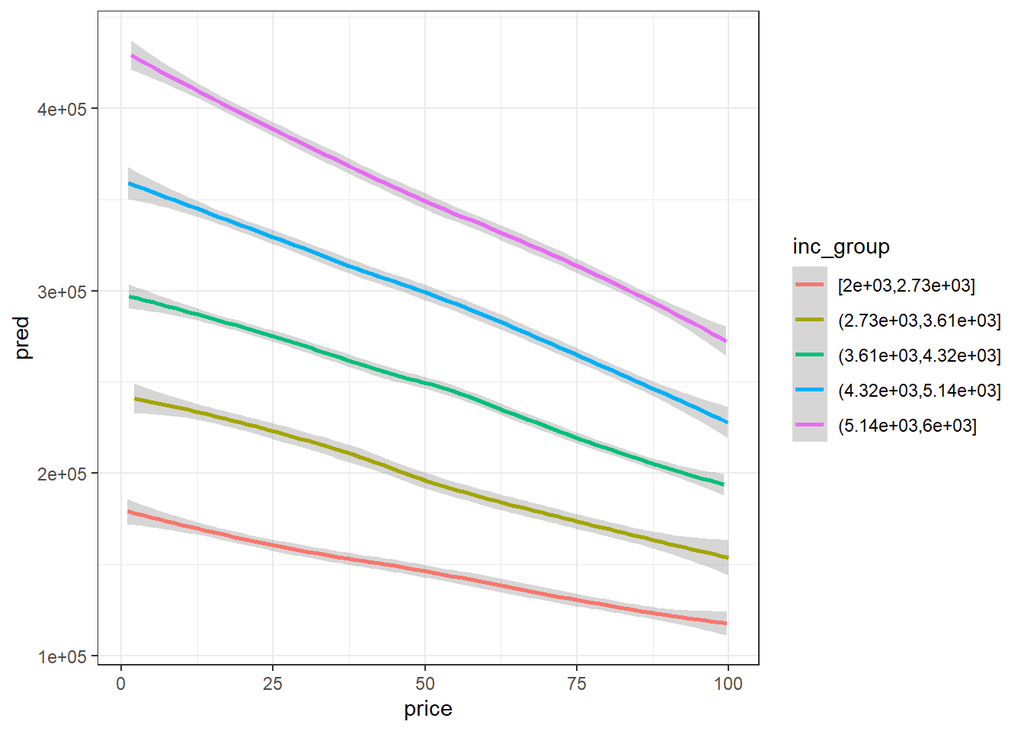

```r
library(tidyverse)
# try out how interaction works
df <- tibble(
  price = seq(1, 100, length.out = 1000),
  inc = runif(1000, 2000, 6000),
  temp = 60,
)


df %>%
  mutate(inc_group = cut_number(inc, 5),
         pred = -6329.81 + 23.35*price + 78.08*inc + 2.82*temp + -0.28*price*inc) %>%
  ggplot(aes(price, pred, colour = inc_group)) +
  geom_smooth() +
  theme_bw()
```

Basiseffekte: Je höher einkommen und je höher der Preis, desto mehr wird verkauft. Aber: insgesamt je höher der Preis, desto weniger wird gekauft, dieser Effekt ist stärker bei höheren Einkommen. Diese kaufen zwar mehr, reagieren aber “stärker” auf die Preisänderung.

# (c) Interpret the other parameters, if they are significant.

Höhere Temperatur und höheres Einkommen führen zu mehr verkauftem Eis, wenn andere gleich bleiben.

# (d) How large are the variance of the error term and the adjusted R-squared (interpret the figures)?

Varianz des Fehlers: Im Mittel weicht unsere Schätzung um 30.94^2 von den wahren Werten ab.

Adjusted R-squared: 0.698, das ist recht hoch, allerdings kann ca. ein drittel der Varianz nicht erklärt werden, weil mglw. relevante Parameter fehlen.

# (e) What is the confidence interval of the temperature effect?

```r
# t mit 24 freiheitsgraden
#
# t wert aus tabelle ist nicht t wert, den wir für konfidenzintervall benötigen
interval <- qnorm(.975) * 0.42
# upper bound:
2.82 +  interval
```

```
## [1] 3.643185
```

```r
# lower bound
2.82 - interval
```

```
## [1] 1.996815
```